# Análisis de Series Temporales

Santiago B. Pérez Pita - santibreo@gmail.es

08 mayo, 2019

# Series Temporales

## Ejercicio 1

##### *El proceso de modelización de series temporales implica una serie de etapas. Ordene cronológicamente (añadiendo un número de orden 1,2,3,…) cada una de las siguientes etapas en el proceso de Análisis series temporales. Discuta brevemente si lo considera preciso*

0. Representación gráfica de la serie (permea todo el proceso)
1. Análisis de datos anómalos y tratamiento en su caso
2. Análisis de datos faltantes e interpolación en su caso
3. Desestacionalización de la serie
4. Test de Raices Unitarias
5. Análisis de la Cointegración a Largo Plazo (sujeto a la disponibilidad de otras series)
   - Diagnosis de los Residuos: Test Ljung-Box (para la regresión de cointegración)
   - Diagnosis de los Residuos: Test BDS (para la regresión de cointegración)
6. Diferenciación de la Serie para conseguir Estacionariedad
7. Modelización con modelos ARMA/ARMAX
8. Análisis de la homocedasticidad de los residuos y modelización ARMA/GARCH
9. Diagnosis de los Residuos: Test Ljung-Box
10. Diagnosis de los Residuos: Test BDS

## Ejercicio 2

##### *A continuación le mostramos el gráfico de la serie de PIB, datos Brutos, Índice de Volumen. ¿Aprecia a simple vista algún tipo de comportamiento en la serie que requiera su consideración?*

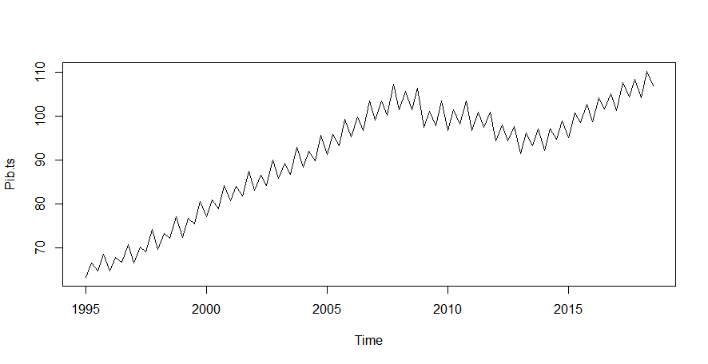

PIB - Índice de Volumen

No podemos descartar la presencia del **efecto calendario** pero no es algo reconocible a simple vista sobre la serie.

## Ejercicio 3

##### *Indique que transformación realiza cada una de estas sentencias de código R aplicadas sobre la serie de frecuencia trimestral llamada y.ts*

```r
yy.ts<-(y.ts/stats::lag(y.ts,k = -4)-1)
```

```r
yy.ts<-(y.ts/stats::lag(y.ts,k = -1)-1)
```

```r
yy.ts<-y.ts[abs(scores(y.ts, type="z"))<=2]
```

3. Esta línea devuelve los valores de la serie que están a dos desviaciones estándar o menos de la media. La función *scores(…, type=z)* normaliza los datos mediante: $x' = \tfrac{x - \bar{x}}{s_x}$.

```r
yy.ts<-ts(zoo::na.StructTS(y.ts), start=start(y.ts), end=end(y.ts), frequency=frequency(y.ts))
```

4. Esta línea emplea un filtro de Kalman estacional para rellenar los *NANs* presentes en la serie, y devuelve la serie sin ellos.

```r
yy.ts<-ta(y.ts, conversion = "average", to="quarterly")
```

22. Esta línea lo que hace es promediar el valor de la serie en una ventana trimestral que la recorre de principio a fin, dado que la serie del enunciado es trimestral, no apreciaríamos ningún efecto, tendría más sentido emplear *to=“annual”* o *to=“monthly”*.

## Ejercicio 4

##### *Explique brevemente que es el componente de Semana santa y calendario de una serie temporal. ¿En qué otros componentes se puede descomponer una serie temporal?*

Llamamos **componente calendario** a aquel comportamiento de la serie debido puramente a efectos relacionados con el calendario, con la forma definida adhoc por nosotros para regular el tiempo, por ejemplo, el efecto del número de días laborales de los meses, las festividades, la no coincidencia entre año natural y lectivo, etc. El componente Semana Santa se puede identificar, por lo tanto, como un efecto calendarío, ya que consite en comportamientos irregulares de la serie en torno a estas fechas, en las que posiblemente exista una disminución en la producción y un aumento en el consumo, por ejemplo. A veces es sútil la diferencia con la **componente estacional** ya que esta componente recoge un efecto sobre la serie que se repite cada cierto periodo de tiempo y el calendario tiene sus propios periodos, la mejor forma de distinguirlas es pensar si el efecto se mantendría si cambiásemos el calendario, Aparte de las componentes comentadas nos faltan dos, por un lado la **tendencia** que recoge el movimiento promedio de la serie a lo largo del tiempo, y nos permite identificar un comportamiento general, por el otro el **error** que se trata de la componente que no somos capaces de explicar de la serie, aquella que se comporta de forma de completamente aleatoria y en la que no identificamos ningún patrón.

##### *Suponga que utiliza la función `seas()` de la librería de R seasonal para descompner la serie temporal trimestral y.ts*

```r
y_sa<-seasonal::seas(y.ts)
```

##### *¿Con qué comando podría guardar en otra serie que se llamase `yy.ts` el componente de ciclo y tendencia de dicha descomposición `y_sa`?*

Para extraer el componente estacional podemos usar `seasonal(y_sa)` y para el componente de tendencia `trend(y_sa)`, aunque esto funciona mucho mejor aplicado sobre la salida de la función `decompose`, pese a que esta función aplica un modelo de **media móvil** más simple.

## Ejercicio 5

##### *Suponga que se ha obtenido el siguiente resultado al aplicar el test de Dikey-Fuller ampliado a la serie desestacionalizada y.ts y a su primera y segunda diferencia*

```r
    Augmented Dickey-Fuller Test

data:  y.ts
Dickey-Fuller = -1.7225, Lag order = 4, p-value = 0.691
alternative hypothesis: stationary


    Augmented Dickey-Fuller Test

data:  diff(y.ts)
Dickey-Fuller = -2.2925, Lag order = 4, p-value = 0.4556
alternative hypothesis: stationary


    Augmented Dickey-Fuller Test

data:  diff(y.ts, differences = 2)
Dickey-Fuller = -5.998, Lag order = 4, p-value = 0.01
alternative hypothesis: stationary
```

##### *¿Para qué sirve este test?, ¿cuál es la hipótesis nula y que significa?¿cuál sería el orden de integración de la serie y.ts?*

La **prueba de Dickey-Fuller** trata de determinar si existen raíces unitarias de la serie temporal, lo que implicaría que NO es estacionaria. La hipótesis nula (**$H_0$**) es que si existen tales raices (luego que la serie no es estacionaria) y la rechazaremos cuando el p-valor sea inferior a una significancia establecida (pongamos 0.05). De esta forma el orden de integración de la serie sería 2 (**$I(2)$**) ya que el p valor asociado a las segundas diferencias es 0.01 < 0.05.

## Ejercicio 6

##### *¿En qué consiste la cointegración de dos series temporales? Explique la estrategia empírica a seguir para contrastar si dos series temporales están cointegradas o no*

Dos series temporales ${X, Y}$ decimos que están cointegradas si ambas poseen el mismo orden de integración $(X \sim I(d)$ e $Y \sim I(d)$) y además existen los coeficientes ${\alpha, \beta}$ tal que: $Z = \alpha X + \beta Y \sim I(0)$, de esta forma nos garantizamos que existe relación y que dicha relación no es espuria. El procedimiento empírico puede consitir en proceder a la comprobación de las condiciones descritas anteriormente o se puede seguir el **método de Engle-Granger** que consiste en comprobar si el orden de integración de los residuos del **modelo de regresión de cointegración** es menor al de las series.

## Ejercicio 7

##### *Explique en qué consisten los modelos de corrección del error. ¿Por qué se dice que son modelos que combinan el largo plazo con el análisis a corto plazo?*

Los **modelos de corrección del error** emplean la desviación a largo plazo existente entre las series temporales cointegradas y su modelo de regresión de cointegración (tendencia) para definir su dinámica a corto plazo. Se definen mediante la formula:
$$\Delta y_t = \phi_0 - \gamma_1 \hat{\pi}_{t-1} + \sum_{j=1}^J \phi_{1j}\ \Delta x_{t-j} + \sum_{k=1}^K \phi_{2k}\ \Delta y_{t-k} + a_t\\
Donde:\ \hat{\pi}_{t-1} = y_{t-1} - \hat{y}_{t-1} = y_{t-1} - \hat{\beta}_0 - \hat{\beta}_1 x_{t-1} = \text{diferencia serie - tendencia último periodo}$$

## Ejercicio 8

### 8.1

##### *¿Qué es el coeficiente de correlación cruzada entre dos series temporales?. A la vista de este ccf entre la serie ICC.ts.Trim (Indice de Comfianza del Consumidor Trimestral) y la serie TPIB.ts (Tasa de Crecimiento del PIB), ¿diría que la máxima correlación entre ambas series es contemporánea?, ¿hay alguna serie que adelante el comportamiento a la otra?*

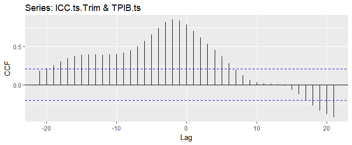

Correlación Cruzada. ICC - PIB

El **coeficiente de correlación cruzada** entre dos series temporales es:
$$r_{xy}(T) = \frac{\sigma_{xy}(T)}{\sqrt{\sigma_{xx}(0)\ \sigma_{yy}(0)}}\\
\text{con: }\ \sigma_{xy}(T) = \frac{1}{N-1} \sum_{t=1}^N(x_{t-T} - \bar{x})(y_t - \bar{y})$$
Que es la definición del coeficiente de correlación entre dos variables cualesquiera pero una de ellas la retrasamos $T$ periodos, de forma que el coeficiente va variando según lo haga el valor de $T$.

Para las variables de la imagen, vemos que el máximo de la función de correlación cruzada se produce en $T=-2$, es decir, que el PIB tarda seis meses en reaccionar al comportamiento del ICC, o con mayor lógica, que los consumidores anticipan seis meses el comportamiento del PIB.

### 8.2

##### *¿Qué es la causalidad en sentido de Granger? Observe los siguientes resultados del test de granger de causalidad entre ICC.ts.Trim y la serie TPIB.ts, podría afirmar que es el ICC (Indice de confianza del consumidor la serie que adelanta al Crecimiento del PIB, os es justo al contrario?¿por qué?*

```r
> library(lmtest)
> grangertest(ICC.ts.Trim, TPIB.ts, order=2)
Granger causality test

Model 1: TPIB.ts ~ Lags(TPIB.ts, 1:2) + Lags(ICC.ts.Trim, 1:2)
Model 2: TPIB.ts ~ Lags(TPIB.ts, 1:2)
  Res.Df Df      F    Pr(>F)
1     84
2     86 -2 15.889 1.404e-06 ***
---
Signif. codes:  0 ‘***’ 0.001 ‘**’ 0.01 ‘*’ 0.05 ‘.’ 0.1 ‘ ’ 1
> grangertest(TPIB.ts, ICC.ts.Trim, order=2)
Granger causality test

Model 1: ICC.ts.Trim ~ Lags(ICC.ts.Trim, 1:2) + Lags(TPIB.ts, 1:2)
Model 2: ICC.ts.Trim ~ Lags(ICC.ts.Trim, 1:2)
  Res.Df Df      F Pr(>F)
1     84
2     86 -2 0.2956 0.7449
```

La **causalidad den sentido Granger** alude exclusivamente a la predicción, y se emplea para determinar si una serie es útil de cara a predecir el comportamiento de otra. Esta causalidad no pretende captar la presencia de efectos comunes y es incapaz además de captar relaciones instantáneas o no lineales, no obstante es un concepto fuertemente asentando en estadística dada su simplicidad computacional.

A la vista de los resultados del test, que determina si la serie *X* (primer argumento) incorpora información a la predicción de la serie *Y* (segundo argumento), frente al uso exclusivamente del pasado de la serie *Y*. Mirando los valores de la significancia, podemos decir que claramente el ICC es útil a la hora de describir el comportamiento del PIB, ya que como vimos en el gráfico ccf va por delante 6 meses (2 *lags*).

## Ejercicio 9

##### *¿Qué es un modelo ARIMA?. ¿Podría escribir la forma analítica que tendría un proceso ARIMA (2,1,1)?*

Los **modelos AutoRegresive Integrated Moving Average (ARIMA)** tratan de explicar el comportamiento de una serie temporal mediante su pasado. Los modelos ARIMA para series temporales sin componente estacional suelen denotarse ARIMA(p, d, q) donde la p es el número de *lags* involucrados, d es el orden de diferenciación requerido por la serie hasta ser estacionaria y q es el orden de la regresión lineal que explica el error.

La forma más elegante de describirlo matemáticamente es partiendo de un modelo ARMA(p, q) (sin parte integrada):
$$X_t = AR(p) + MA(q) = \alpha_1 X_{t-1} + \alpha_2 X_{t-2} + \ldots + \alpha_p X_{t-p} + \epsilon_t + \theta_1 \epsilon_{t-1} + \theta_2 \epsilon_{t-2} + \ldots + \theta_q \epsilon_{t-q}$$
Si llamamos $L^k$ al operador *lag* que actúa tal que: $L^k X_t = X_{t-k}$ podemos escribir el modelo ARMA(p, q) como:
$$X_t = \left(\sum_{i=1}^p \alpha_i L^i\right) X_t + \left(\sum_{i=1}^q \theta_i L^i\right) \epsilon_t + \epsilon_t \longrightarrow \left(1 - \sum_{i=1}^p \alpha_i L^i\right) X_t = \left(1 + \sum_{i=1}^q \theta_i L^i\right) \epsilon_t$$
Finalmente para incorporar la parte integrada ($I(d)$) debemos suponer que el operador $\left(1 - \sum_{i=1}^p \alpha_i L^i\right)$ tiene como factor una raíz unitaria que se repite $d$ veces: $\left(1 - \sum_{i=1}^p \alpha_i L^i\right) = \left(1 - \sum_{i=1}^{p-d} \phi_i L^i\right) \cdot (1 - L^1)^d$. De esta forma ya podríamos definir nuestro modelo ARIMA(p’, q, d) como:
$$\left(\left(1 - \sum_{i=1}^{p'} \phi_i L^i\right) \cdot (1 - L^1)^d \right)X_t = \left(1 + \sum_{i=1}^q \theta_i L^i\right) \epsilon_t\\
con\ p' = p - d$$
Si ahora hacemos $p'=2, d=1, q=1$ nos queda ARIMA(2,1,1):
$$\left(\left(1 - \phi_1 L^1 - \phi_2 L^2\right) \cdot (1 - L^1)\right)X_t = \left(1 + \theta_1 L^1\right) \epsilon_t\ \\
X_t = \phi_1 X_{t-1} + \phi_2 X_{t-2} + X_{t-1} - \phi_1 X_{t-2} - \phi_2 X_{t-3} + \theta_1 \epsilon_{t-1} + \epsilon_t \\
X_t - X_{t-1} = \phi_1 \left(X_{t-1} - X_{t-2}\right)+ \phi_2 \left(X_{t-2} + X_{t-3}\right) + \theta_1\epsilon_{t-1} + \epsilon_t \\$$
Es importante señalar que el número de parámetros a ajustar para obtener el modelo es $p + q$ (3 en nuestro caso). Para las series temporales con componente estacional se anaden los índices (P, Q, D) que cumplen la misma función que (p, q, d) para la parte no estacionaria pero sobre la componente estacional.

##### *A continuación se presentan los residuos de un modelo ARMA estimado para la serie del D2ln(PIB). ¿Considera que dicho modelo es aceptable para realizar predicciones?. **Justifique su respuesta.***

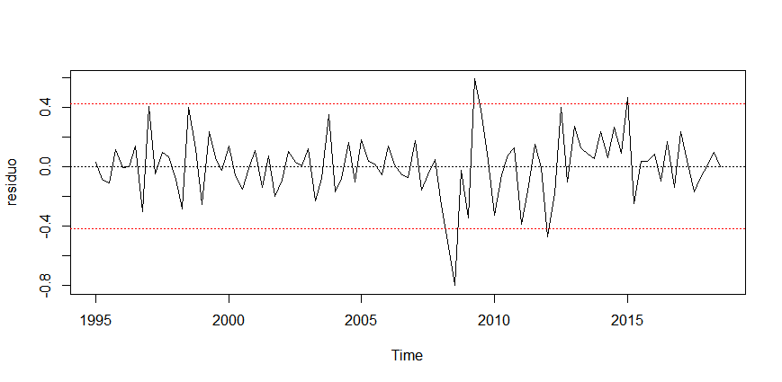

Residuo

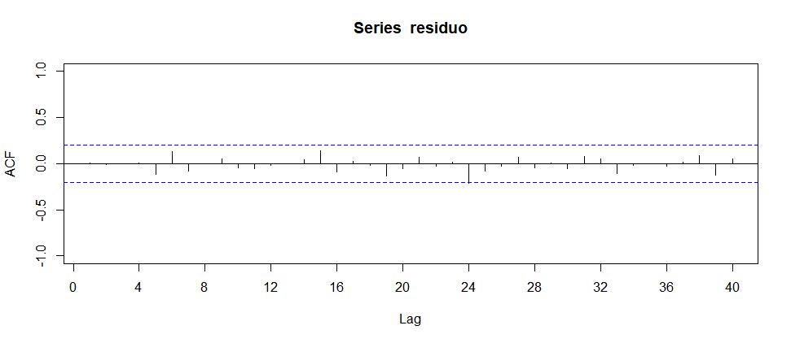

Autocorrelación Residuo

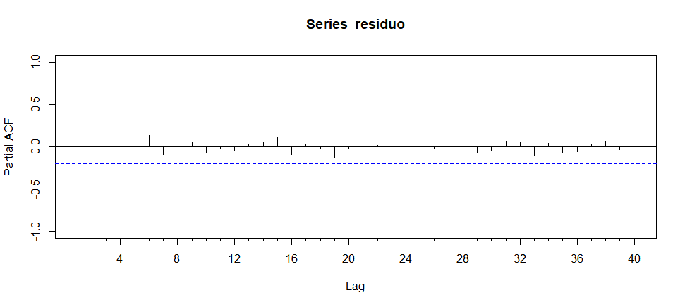

Autocorrelación Parcial Residuo

```r
Box-Ljung test
data:  residuo

lag: 1
X-squared = 0.0075066, df = 1, p-value = 0.931

lag: 2
X-squared = 0.018505, df = 2, p-value = 0.9908

lag: 3
X-squared = 0.018556, df = 3, p-value = 0.9993

lag: 4
X-squared = 0.030287, df = 4, p-value = 0.9999

lag: 5
X-squared = 1.3379, df = 5, p-value = 0.931

lag: 6
X-squared = 3.0086, df = 6, p-value = 0.8078

lag: 7
X-squared = 3.72, df = 7, p-value = 0.8114

lag: 8
X-squared = 3.7203, df = 8, p-value = 0.8814

     BDS Test

data:  residuo

Embedding dimension =   2  3  4  5  6  7  8  9 10

Epsilon for close points =  0.2148

Standard Normal =
       [ 0.2148 ]
[ 2 ]      1.7362
[ 3 ]      2.2553
[ 4 ]      1.7864
[ 5 ]      1.4134
[ 6 ]      1.0792
[ 7 ]      1.0032
[ 8 ]      0.6781
[ 9 ]      0.9124
[ 10 ]     1.0209

p-value =
       [ 0.2148 ]
[ 2 ]      0.0825
[ 3 ]      0.0241
[ 4 ]      0.0740
[ 5 ]      0.1575
[ 6 ]      0.2805
[ 7 ]      0.3158
[ 8 ]      0.4977
[ 9 ]      0.3615
[ 10 ]     0.3073
```

Mirando los p-valores tanto para el **test Box-Ljung** como para el **BDS** podemos ver que todos los valores salvo el del test BDS para 3 dimensiones embebidas, son superiores a 0.05, luego no podemos rechazar la hipótesis nula en ninguno de los casos. De esta forma diremos que los residuos de nuestro modelo están independientemente distribuidos (test Ljung-Box) o indenpendiente e idénticamente distribuidos (test BDS) lo que concuerda con los gráficos de autocorrelación proporcionados donde para ningun orden (*lag*) encontramos valores elevados, y con la imagen de los propios residuos, donde vemos valores aleatorios distribuidos normalmente. Si los residuos se comportan como ruido blanco es muy probable que el modelo prediga con bastante solvencia el comportamiento de la serie, ya que debe estar recogiendo la parte explicable de su dinámica.

## Ejercicio 10

##### *De los diferentes indicadores adelantados para la predicción del PIB que se vieron en clase:*

- **IndSintActEc** : “I. Sintético Actividad (CVEC).Indice (2010=100)”
- **AfiliadoSS**: “Afiliados Seguridad Social. Total. (Miles)”
- **ConsEnergEle**: “Consumo energía eléctrica (CCal y Temp.). Millones de Kwh.”
- **IndSentEc**: “I. Sent. Económico (1990 2017=100)”, Fuente Eurostat, promedio Indices Confianza Industrial, Servicios, Consumidores, Construción y Comercio
- **VentasGrdsEmpr**: “Total Ventas grandes empresas.(CVEC).Indice (2013=100).”
- **ICC**: Indice de Confianza del Consumidor
- **ComerMenor**: Índice de Comercio Minorista
- **OCUPADOS**: Número de OCUPADOS (EPA)

##### *¿Cuál de todos ellos cree que es el más adecuado para adelantar el comportamiento de la tasa de crecimiento interanual del PIB?. ¿Se atrevería a adelantar cuál será la tasa de crecimiento interanual del PIB para el cuarto trimestre de este 2018?*

En primer lugar debo indicar que no he encontrado en los ficheros trabajados en clase la variable *ComerMenor* y en ninguno de los sets de datos un índice de comercio minorista, así que he decidido sustituir este indicador por la serie temporal del *IBEX35*, ya que me parece que podía ser de interés.

El código empleado para contestar a las preguntas lo adjunto a continuación, con él se pueden obtener los valores y gráficos que utilizaré en adelante para justificar mis respuestas. Esencialmente lo que he hecho ha sido coger los indicadores mencionados y elaborar con ellos un modelo de regresión lineal de sus series, o de sus series diferenciadas, sobre la tasa de crecimienciento interanual del PIB. He estudiado además la cointegración entre las series, y probado incluso algunos **modelos ARMAX**, no obstante mi tiempo no es infinito, este procedimiento estaba recogido entre los procedimientos empleados en clase, y aunque puedan aparecer relaciones espúreas (todas ellas lo son ya que en el estudio de la cointegración nunca obtuve un estadístico superior a los valores tabulados para el **test de cointegración de Phillips–Ouliaris**, lo cual me resultó francamente desalentador), lo resultados parecen bastante buenos. El procedimiento puede reproducirse mediante la ejecución del siguiente código.

```r
# Algunas librarÍas generales ----
library(dplyr)  # Filtrar y seleccionar variables
library(ggplot2) # Para realizar gr?ficos
library(tseries) # Adf.test, kpss.test, bds.test, get.hist.quote, portfolio.optim, surrogate, arma, garch
library(forecast) # interpolar, ndiffs para saber el n?mero de diferencias, adf, ggCcf(x,y): [xt+k, yt], ggAcf, autoarima
library(zoo) #diferentes procesos para series temporales
library(stargazer) # para tablas de resultados
library(tempdisagg) #ta agrega (reduce frecuencia), td desagrega (aumenta frecuencias)
library(pxR) # para leer datos desde archivos .px pc-axis del INE pxR::read.px()
library(eurostat) #para leer datos de eurostat
library(data.table)
library(xts) #para series temporales grandes
library(dygraphs)
library(outliers) #outlier, rm.outlier, scores, chisq.out.test # para detectar outliers o datos an?malos ojo serie estacionaria
library(seasonal) #Para extraer cmponente estacional
library(tempdisagg) #ta agrega (reduce frecuencia), td desagrega (aumenta frecuencias)
library(urca)# Para test de ra?ces Unitarias
library(ecm) #para modelos de correci?n de error
library(lmtest) #varios test de modelos de regresi?n
library(sandwich) #estimaci?n robusta matriz de varianzas y covarianzas
library(rugarch) # estimaci?n de modelos GARCH


#_______________________________________________________________________________________
# 1 Carga los datos ----
# 1.0 Carga de Datos desde archivos RData ----

load(file="DATOCU.RData") # aquí he guardado las serie de Ocupados y
                          # y de Tasa de Paro de la EPA

# 1.1. Carga de datos desde archivos (csv, excel, etc) ----

# Ejemplo: Series temporales de Coyuntura Econ?mica
# Bolet?n de Coyuntura Económica Semanal del Ministriode Economía
# http://serviciosede.mineco.gob.es/indeco/
# tengo que descargar la hoja y desproteger la
# la hoja Cuadro2Mensual (pestaña Revisar. grupo Cambios, bot?n Desproteger hoja) y grabar

library(readxl)
IndicesMineco<-read_excel("indicador.xls",sheet = "Cuadro2 Mensual",skip = 2)
# Selecciono
datosMineco<-IndicesMineco[,c(1,2,3,4,7,8)]
datosMineco.desc<- names(datosMineco)
names(datosMineco)<-c("Periodos","IndSintActEc","AfiliadoSS","ConsEnergEle","IndSentEc", "VentasGrdsEmpr" )
str(datosMineco)
datosMineco$IndSintActEc<-as.numeric(datosMineco$IndSintActEc)
datosMineco$AfiliadoSS<-as.numeric(datosMineco$AfiliadoSS)
datosMineco$ConsEnergEle<-as.numeric(datosMineco$ConsEnergEle)
datosMineco$IndSentEc<-as.numeric(datosMineco$IndSentEc)
datosMineco$VentasGrdsEmpr<-as.numeric(datosMineco$VentasGrdsEmpr)

# Periodos : "Periodos"
# IndSintActEc : "I. Sintético Actividad (CVEC).Indice (2010=100)"
# AfiliadoSS: "Afiliados Seguridad Social. Total. (Miles)"
# ConsEnergEle: "Consumo energía el?ctrica (CCal y Temp.). Millones de Kwh."
# IndSentEc: "I. Sent. Económico (1990 2017=100)", Fuente Eurostat, promedio Indices Confianza Industrial, Servicios, Consumidores, Construci?n y Comercio
# VentasGrdsEmpr: "Total Ventas grandes empresas.(CVEC).Indice (2013=100)."

# Construcción del Indice Sintético de Actividad Económica
  # VGE: Ventas en grandes empresas 0,89
  # AFI: Afiliados a la Seguridad Social no agrarios 0,88
  # CEM: Consumo aparente de cemento 0,86
  # IMPNE: Importaciones no energ?ticas 0,67
  # ELE: Consumo de energ?a el?ctrica 0,62
  # IPI: Índice de producci?n industrial 0,60
  # ENT: Entrada de turistas 0,54
  # REP: Transporte RENFE pasajeros 0,54
  # AER: Tráfico aéreo de pasajeros 0,49
  # ICE: Indicador de Clima Econ?mico 0,42
  # REM: Transporte RENFE mercanc?as 0,21
  # FIN: Cr?dito a empresas y familias deflactado por IPC subyacente 0,17

# 1.2. Descarga de datos Online desde el INE ----
library(pxR) # para leer datos desde archivos .px pc-axis del INE pxR::read.px()

#   References: http://www.ine.es/dyngs/INEbase/listaoperaciones.htm
#   a) Series del PIB: Contabilidad Nacional TRIMESTRAL

#   INEbase < Economía < Cuentas Econ?micas < Contabilidad nacional trimestral (CNTR) de Espa?a <  Informaci?n detallada
#   Pestalla resultados (serie base 2010); Enlaces relacionados (serie bases anteriores)

url<-"http://www.ine.es/jaxiT3/files/t/es/px/28603.px?nocab=1"
datos<-as.data.frame(read.px(url), stringsAsFactor=FALSE)  #como un data.frame
table(datos$Agregados.macroeconómicos)
Pib<-datos%>%
  dplyr::filter(Niveles.y.tasas =="Dato base")%>%
  dplyr::filter(Agregados.macroeconómicos=="Producto interior bruto a precios de mercado")%>%
  dplyr::mutate(ANO=as.numeric(substr(Periodo,1,4)))%>%
  dplyr::mutate(Tipo.de.dato=ifelse(Tipo.de.dato=="Datos no ajustados de estacionalidad y calendario", "Bruto", "Desestacionalizado"))%>%
  dplyr::mutate(TRIM=as.numeric(substr(Periodo,6,7)))%>%
  dplyr::mutate(tiempo=ANO+TRIM*0.25-0.25)%>%
  dplyr::arrange(Tipo.de.dato,tiempo)%>%
  dplyr::select(Periodo, Tipo.de.dato, ANO, TRIM, tiempo, value)

# 1.3. Descarga de datos desde Eurostat ----
library(eurostat)
# Busco datos por tablas de Eurostat, ejemplo: PIB
query<-search_eurostat("GDP", type="table", fixed=T)
# View(query[1:5,])

# Busco los indicadores de Confianza
#http://appsso.eurostat.ec.europa.eu/nui/show.do?dataset=ei_bssi_m_r2&lang=en#

query<-search_eurostat("Sentiment", type="all")
# View(head(query,10))
temp.Eurostat<-get_eurostat("ei_bssi_m_r2",time_format = "num",type ="code", stringsAsFactors = FALSE,cache = FALSE) #,time_format = "raw",type ="code", stringsAsFactors = TRUE)
#Para ver que significan los campos
label_eurostat_vars(temp.Eurostat)
# aÑadir los labels
temp.Eurostat<-label_eurostat(temp.Eurostat, code=names(temp.Eurostat))
# Ahora tendr?a que seleccionar el dato de Espa?a, Francia, Italia, Reino Unido y Alemania, por ejemplo
# View(temp.Eurostat %>%
# distinct(indic, indic_code))

# BS-CCI-BAL: Construction confidence indicator
# BS-CSMCI-BAL: Consumer confidence indicator
# BS-ESI-I: Economic sentiment indicator
# BS-ICI-BAL: Industrial confidence indicator
# BS-RCI-BAL: Retail confidence indicator
# BS-SCI-BAL: Services Confidence Indicator

Sent.Eurostat<-temp.Eurostat %>%
  filter(geo_code %in% c("ES")) %>%
  filter(indic_code=="BS-CSMCI-BAL") %>%
  filter(s_adj_code=="SA") %>%
  arrange(time_code)
```

```r
# 1.4. Descarga de datos desde Yahoo Finanzas (librer?a quantmod)----
library(tseries) # get.hist.quote, portfolio.optim, surrogate, arma, garch
# descargamos la serie del IBEX35
# desde yahoo finanzas diarios, o desde Alpha Vantage (quantmod) datos minuto a minuto
Ibex <- get.hist.quote(instrument="^ibex", retclass="zoo")

# 2. Formateo de las series ----
# Extraigo de los datos cargados todas las series que voy a emplear y les asigno la misma frecuencia
# Creo dos versiones de la serie del PIB
datos<- Pib %>%
  filter(Tipo.de.dato=="Bruto") %>%
  arrange(tiempo) %>%
  select(tiempo,value)

Pib.ts<-ts(data = datos$value, start = c(1995,1), frequency = 4)

datos<-Pib %>%
  filter(Tipo.de.dato=="Desestacionalizado") %>%
  arrange(tiempo) %>%
  select(tiempo,value)

Pib.SA.ts<- ts(data = datos$value, start = c(1995,1), frequency = 4)
objetivo.SA<- datos$value[nrow(datos)-1]

# Creo la serie De Ocupados
Ocu.ts<-ts(DATOCU$OCU, start=1976.50, frequency = 4)

# Creo la serie De ICC
ICC.ts<-ts(Sent.Eurostat$values, start=min(Sent.Eurostat$time), frequency = 12)
ICC.ts<- ta(ICC.ts, conversion="last", to='quarterly', rm.na=TRUE)

# Creo la serie del IBEX
Ibex.zoo <- aggregate(Ibex$Close, as.yearqtr, mean)

# Creo las series Mineco
IndicesMineco.ts<- ts(datosMineco[,2:6], start=1995, frequency = 12)
IndicesMineco.ts<- ta(IndicesMineco.ts, conversion="average", to='quarterly')

# Juntamos las series (comando intersec, para eliminar valores posteriores al tercer trimestre de 2018)
All.ts<- ts.intersect(IndicesMineco.ts, Ocu.ts, ICC.ts, as.ts(Ibex.zoo), Pib.ts)
colnames(All.ts)<- c("IndSintActEc", "AfiliadoSS", "ConsEnergEle", "IndSentEc", "VentasGrdsEmpr",
                     "Ocu.ts", "ICC.ts", "Ibex.ts", "Pib.ts")

# 3. Gráfico de las series ----
# plot(serie_temporal)  en realidad llama al procedimiento plot.ts, plot.zoo, plot.xts
colfunc<-colorRampPalette(c("firebrick","goldenrod","darkolivegreen3","cornflowerblue", "darkviolet"))
plot(scale(All.ts), plot.type = "single", col=colfunc(ncol(All.ts)))
legend('topleft','groups',colnames(All.ts), lty=1, cex=0.65, lwd=2.5, col=colfunc(ncol(All.ts)))

library(ggplot2)
aux<- as.data.frame(scale(All.ts))[index(All.ts)>2000,]
aux$id = 1:nrow(aux)
aux<- melt(aux, id='id')
ggplot() + geom_line(data = aux, aes(x = id, y = value, color = variable, group = variable), size = 1) +
  labs(title="Todas las series",
       subtitle = "2000Q1 - 2018Q3",
       y= "Valores escalados",
       x= "trimestre")

# 4. Análisis de datos Missing e imputación ----
# Cojo todas las series desde el primer dato no missing, salvo la del IBEX que la cojo un no missing posterior, ya que aún hay
# regiones de timepo amplias sin datos tras el primer missing. Los datos missing intermedios los interpolo.
# Además busco outliers, valores a más de 3 desviaciones típicas de la media

# INDICE DE ACTIVIDAD ECONÓMICA
IndSintActEc.ts<- IndicesMineco.ts[,1]
table(is.na(IndSintActEc.ts)) # No hay missing
which(abs(scores(IndSintActEc.ts, type="z"))>3) # No hay outliers

# AFILIADOS A LA SS
AfiliadoSS.ts<- IndicesMineco.ts[,2]
table(is.na(AfiliadoSS.ts)) # Eliminamos los missing
AfiliadoSS.ts<- window(AfiliadoSS.ts, start=index(AfiliadoSS.ts)[which.min(is.na(AfiliadoSS.ts))])
which(abs(scores(AfiliadoSS.ts, type="z"))>3) # No hay outliers

# CONSUMO ENERGÉTICO
ConsEnergEle.ts<- IndicesMineco.ts[,3]
table(is.na(ConsEnergEle.ts)) # Eliminamos los missing
ConsEnergEle.ts<- window(ConsEnergEle.ts, start=index(ConsEnergEle.ts)[which.min(is.na(ConsEnergEle.ts))])
which(abs(scores(ConsEnergEle.ts, type="z"))>3)

# INDICADOR DE SENTIMIENTO ECONÓMICO
IndSentEc.ts<- IndicesMineco.ts[,4]
table(is.na(IndSentEc.ts)) # No hay missing
which(abs(scores(IndSentEc.t, type="z"))>3) # No hay outliers

# VENTAS DE GRANDES EMPRESAS
VentasGrdsEmpr.ts<- IndicesMineco.ts[,5]
table(is.na(VentasGrdsEmpr.ts)) # Eliminamos los missing
VentasGrdsEmpr.ts<- window(VentasGrdsEmpr.ts, start=index(VentasGrdsEmpr.ts)[which.min(is.na(VentasGrdsEmpr.ts))])
which(abs(scores(VentasGrdsEmpr.ts, type="z"))>3) # No hay outliers

# PERSONAS OCUPADAS
table(is.na(Ocu.ts)) # No hay missing
which(abs(scores(Ocu.ts, type="z"))>3) # No hay outliers

# INDICE DE CONFIANZA DEL CONSUMIDOR
table(is.na(ICC.ts)) # No hay missing
which(abs(scores(ICC.ts, type="z"))>3) # No hay outliers

# IBEX35
Ibex.ts<- as.ts(Ibex.zoo)
table(is.na(Ibex.ts)) # Eliminamos los missing del principio
Ibex.ts<- window(Ibex.ts, start=c(2005,2)) # Inputamos missing
plot(Ibex.ts, lwd=2)
y1<- zoo::na.approx(Ibex.ts)
lines(y1, col="blue",type="p", pch=15, cex=1)
y2<-zoo::na.locf(Ibex.zoo)
lines(y2, col="darkgreen",type="p", pch=17, cex=0.9)
y<- Ibex.ts
y[1]<- zoo::na.approx(Ibex.ts)[1]
y3<-zoo::na.StructTS(y)
lines(y3, col="red",type="p", pch=19, cex=0.8) # Select this
Ibex.ts<- y3
which(abs(scores(Ibex.ts, type="z"))>3) # No hay outliers

# PIB
table(is.na(Pib.ts)) #Elliminamos los missing
which(abs(scores(Pib.ts, type="z"))>3) # No hay outliers


# 5. Desestacionalización ----
# Tendencia + Ciclo + Estacionalidad + SemanaSanta y Efecto Calendario + Errático
library(seasonal)
y<-IndSintActEc.ts
y_trend1<-decompose(y) #se limita a hacer una media movil
y_trend2<-seas(y) # método X13-Seats
plot(y)
lines(y_trend1$trend, col=2)
lines(trend(y_trend2), col=4)# Esta no presenta componente estacional

y<-AfiliadoSS.ts
y_trend1<-decompose(y) #se limita a hacer una media movil
y_trend2<-seas(y) # método X13-Seats
plot(y)
lines(y_trend1$trend, col=2)
lines(trend(y_trend2), col=4)# Esta presenta componente estacional
AfiliadoSS.ts<- trend(y_trend2)


y<-ConsEnergEle.ts
y_trend1<-decompose(y) #se limita a hacer una media movil
y_trend2<-seas(y) # método X13-Seats
plot(y)
lines(y_trend1$trend, col=2)
lines(trend(y_trend2), col=4)# Esta presenta componente estacional
ConsEnergEle.ts<- y_trend1$trend
ConsEnergEle.ts[is.na(ConsEnergEle.ts)]<- trend(y_trend2)[is.na(ConsEnergEle.ts)]

y<-IndSentEc.ts
y_trend1<-decompose(y) #se limita a hacer una media movil
y_trend2<-seas(y) # método X13-Seats
plot(y)
lines(y_trend1$trend, col=2)
lines(trend(y_trend2), col=4)# Esta no presenta componente estacional
```

```r
y<-VentasGrdsEmpr.ts
y_trend1<-decompose(y) #se limita a hacer una media movil
y_trend2<-seas(y) # método X13-Seats
plot(y)
lines(y_trend1$trend, col=2)
lines(trend(y_trend2), col=4)# Esta no presenta componente estacional

y<-Ocu.ts
y_trend1<-decompose(y) #se limita a hacer una media movil
y_trend2<-seas(y) # método X13-Seats
plot(y)
lines(y_trend1$trend, col=2)
lines(trend(y_trend2), col=4)# Esta presenta componente estacional
Ocu.ts<- trend(y_trend2)

y<-ICC.ts
y_trend1<-decompose(y) #se limita a hacer una media movil
y_trend2<-seas(y) # método X13-Seats
plot(y)
lines(y_trend1$trend, col=2)
lines(trend(y_trend2), col=4)# Esta presenta componente estacional
ICC.ts<- trend(y_trend2)

y<-Ibex.ts
y_trend1<-decompose(y) #se limita a hacer una media movil
y_trend2<-seas(y) # método X13-Seats
plot(y)
lines(y_trend1$trend, col=2)
lines(trend(y_trend2), col=4)# Esta no presenta componente estacional

y<-Pib.ts
y_trend1<-decompose(y) #se limita a hacer una media movil
y_trend2<-seas(y) # método X13-Seats
plot(y)
lines(y_trend1$trend, col=2)
lines(trend(y_trend2), col=4)
lines(Pib.SA.ts, col=3)# Esta si presenta componente estacional
Pib.ts<-Pib.SA.ts

# 6. Test de Raices Unitarias y cointegración ----
# Voy a crear dos series independientes
# Tienen algo que ver la una con la otra?
cointegradas<- function(seriex, seriey){
  # 1 Estacionariedad
  series<-ts.intersect(seriey, seriex)
  y = series[,1]
  x = series[,2]

  ggtsdisplay(x)
  ggtsdisplay(y)

  # test de Raices Unitarias
  library(tseries)
  print(adf.test(x))
  print(adf.test(y))

  # Opción uno Diferencio las series y compruebo que el modelo siga siendo válido
  #construyo las series diferenciadas dy dx
  cat("Serie x diferenciada", ndiffs(x), "veces\n")
  cat("Serie y diferenciada", ndiffs(y), "veces\n")
  dy <- diff(y, ndiffs(y))
  dx <- diff(x, ndiffs(x))
  series.dif<- ts.intersect(dy,dx)
  dy<- series.dif[,1]
  dx<- series.dif[,2]

  # Construyo las regresiones entre las series, y entre las series diferenciadas
  coint.reg <- lm(y ~ x)
  summary(coint.reg)
  dif.reg<-lm(dy~dx)
  print(summary(dif.reg))
  library(stargazer)
  stargazer(coint.reg, dif.reg, type="text")

  # Lo ploteamos
  aux<- data.frame(real=y, ajustado=coint.reg$fitted)
  aux$id = 1:nrow(aux)
  aux<- melt(aux, id='id')
  print(ggplot() + geom_line(data = aux, aes(x = id, y = value, color = variable, group = variable), size = 1))

  #Test cointegración Engle-Granger
  # Primera etapa
  # extraigo el error
  coint.err<-residuals(coint.reg)
  plot(coint.err, type="l")

  # A menudo la regresión sobre las series diferenciadas SI pasan los test de cointegración !!!
  # segunda etapa: compruebo si el error es estacionario
  cat("Augmented Dickey Fuller test p-value:", punitroot(adf.test(coint.err)$statistic, trend="nc"), "\n")

  # Phillips–Ouliaris Cointegration Test HO: NO Cointregration
  # null hypothesis that x is not cointegrated.
  library(urca)
  # null hypothesis that x is not cointegrated.
  tru<-ur.df(coint.err, type = c("drift"), lags = 12,
             selectlags = c("BIC"))
  print(summary(tru))
  cat("Augmented Dickey Fuller test p-value:", punitroot(tru@teststat[1], trend="c"), "\n")
  capocointest<-ca.po(series, demean=c("none"), lag=c("long"))
  summary(capocointest)
}

seriey<- Pib.ts
seriex<- IndSintActEc.ts
cointegradas(seriex, seriey)
seriex<- AfiliadoSS.ts
cointegradas(seriex, seriey)
seriex<- IndSentEc.ts
cointegradas(seriex, seriey)
seriex<- ConsEnergEle.ts
cointegradas(seriex, seriey)
seriex<- VentasGrdsEmpr.ts
cointegradas(seriex, seriey)
seriex<- Ocu.ts
cointegradas(seriex, seriey)
seriex<- ICC.ts
cointegradas(seriex, seriey)
seriex<- Ibex.ts
cointegradas(seriex, seriey)


# 7. Modelos de seres temporales Estacionarias ----
# Correlación contemporanea e indicadores adelantados
# Tasa de crecimiento interanual del Pib
obj.comp<- Pib.ts/stats::lag(Pib.ts, -4) -1
objetivo<- as.data.frame(window(obj.comp, start=c(2018,4)))[1,]
seriey<- window(obj.comp, end=c(2018,3))
lin.model<- function(seriey, seriex, nombre){
  ggCcf(seriex, seriey)
  crosscorr<- Ccf(seriex, seriey)
  Ccf.df<- data.frame(values=crosscorr$acf, row.names=crosscorr$lag)
  n_lags<- as.numeric(row.names(Ccf.df)[which.max(Ccf.df$values)])

  # Test de Causalidad de Granger
  library(lmtest)
  grangertest(seriex, seriey, order=2)
  grangertest(seriey, seriex, order=2)

  if(n_lags>0){
    cat(nombre, " es un indicador atrasado ", n_lags, " periodos\n")
  }else if(n_lags<0){
    cat(nombre, " es un indicador adelantado ", n_lags, " periodos\n")
  }else{
    cat(nombre, " es un indicador contemporáneo ", n_lags, " periodos\n")
  }
  seriex2<-stats::lag(seriex, n_lags)
  series<-ts.intersect(seriey,seriex2)
  modelo.lm<-lm(seriey ~ seriex2, data=series)  #ojo, na.action=NULL para las series
  cat("El modelo asociado a la serie lagueada presenta un R2 ajustado de: ", summary(modelo.lm)$adj.r.squared, "\n")
  to.pred<- as.data.frame(window(seriex2, start=c(2018,4)))[1,]
  predicho<- as.numeric(modelo.lm$coefficients[1]) + as.numeric(modelo.lm$coefficients[2])*to.pred
}

# Adaptamos la seriex para que se parezca a la seriey
seriex<- IndSintActEc.ts
plot(scale(seriey), type="l")
lines(scale(seriex), type="l", col=2)
lines(scale(diff(seriex)), type="l", col=4)
# Usamos la seriex que nos convenga
seriex<- diff(seriex)
predicho<- lin.model(seriey, seriex, "IndSintActEc.ts")
cat("Error: ", abs(predicho - objetivo)*100/objetivo, "%\n")

seriex<- AfiliadoSS.ts
plot(scale(seriey), type="l")
lines(scale(seriex), type="l", col=2)
lines(scale(diff(seriex)), type="l", col=4)
# Usamos la seriex que nos convenga
seriex<- diff(seriex)
predicho<- lin.model(seriey, seriex, "AfiliadoSS.ts")
cat("Error: ", abs(predicho - objetivo)*100/objetivo, "%\n")

seriex<- IndSentEc.ts
plot(scale(seriey), type="l")
lines(scale(seriex), type="l", col=2)
lines(scale(diff(seriex)), type="l", col=4)
# Usamos la seriex que nos convenga
predicho<- lin.model(seriey, seriex, "IndSentEc.ts")
cat("Error: ", abs(predicho - objetivo)*100/objetivo, "%\n")
```

```r
seriex<- ConsEnergEle.ts
plot(scale(seriey), type="l")
lines(scale(seriex), type="l", col=2)
lines(scale(diff(seriex)), type="l", col=4)
# Usamos la seriex que nos convenga
seriex<- diff(seriex)
predicho<- lin.model(seriey, seriex, "ConsEnergEle.ts")
cat("Error: ", abs(predicho - objetivo)*100/objetivo, "%\n")

seriex<- VentasGrdsEmpr.ts
plot(scale(seriey), type="l")
lines(scale(seriex), type="l", col=2)
lines(scale(diff(seriex)), type="l", col=4)
# Usamos la seriex que nos convenga
seriex<- diff(seriex)
predicho<- lin.model(seriey, seriex, "VentasGrdsEmpr.ts")
cat("Error: ", abs(predicho - objetivo)*100/objetivo, "%\n")

seriex<- Ocu.ts
plot(scale(seriey), type="l")
lines(scale(seriex), type="l", col=2)
lines(scale(diff(seriex)), type="l", col=4)
# Usamos la seriex que nos convenga
seriex<- diff(seriex)
predicho<- lin.model(seriey, seriex, "Ocu.ts")
cat("Error: ", abs(predicho - objetivo)*100/objetivo, "%\n")

seriex<- ICC.ts
plot(scale(seriey), type="l")
lines(scale(seriex), type="l", col=2)
lines(scale(diff(seriex)), type="l", col=4)
# Usamos la seriex que nos convenga
seriex<- diff(seriex)
predicho<- lin.model(seriey, seriex, "ICC.ts")
cat("Error: ", abs(predicho - objetivo)*100/objetivo, "%\n")

seriex<- Ibex.ts
plot(scale(seriey), type="l")
lines(scale(seriex), type="l", col=2)
lines(scale(diff(seriex)), type="l", col=4)
# Usamos la seriex que nos convenga
seriex<- diff(seriex)
predicho<- lin.model(seriey, seriex, "Ibex.ts")
cat("Error: ", abs(predicho - objetivo)*100/objetivo, "%\n")
# 8. Los mejores ----
lin.model2<- function(seriey, seriex, nombre){
  ggCcf(seriex, seriey)
  crosscorr<- Ccf(seriex, seriey)
  Ccf.df<- data.frame(values=crosscorr$acf, row.names=crosscorr$lag)
  n_lags<- as.numeric(row.names(Ccf.df)[which.max(Ccf.df$values)])

  # Test de Causalidad de Granger
  library(lmtest)
  grangertest(seriex, seriey, order=2)
  grangertest(seriey, seriex, order=2)

  if(n_lags>0){
    cat(nombre, " es un indicador atrasado ", n_lags, " periodos\n")
  }else if(n_lags<0){
    cat(nombre, " es un indicador adelantado ", n_lags, " periodos\n")
  }else{
    cat(nombre, " es un indicador contemporáneo ", n_lags, " periodos\n")
  }
  seriex2<-stats::lag(seriex, n_lags)
  series<-ts.intersect(seriey,seriex2)
  modelo.lm<-lm(seriey ~ seriex2, data=series)  #ojo, na.action=NULL para las series
  cat("El modelo asociado a la serie lagueada presenta un R2 ajustado de: ", summary(modelo.lm)$adj.r.squared, "\n")
  to.pred<- data.frame(row.names=index(seriex2), seriex2)["2019.25",]
  as.numeric(modelo.lm$coefficients[1]) + as.numeric(modelo.lm$coefficients[2])*to.pred
}
seriex<- AfiliadoSS.ts
seriex<- diff(seriex)
pred1<- lin.model2(obj.comp, seriex, "AfiliadosSS")
seriex<- ICC.ts
seriex<- diff(seriex)
pred2<- lin.model2(obj.comp, seriex, "AfiliadosSS")
aux<- stats::lag(Pib.ts, -4)
pred<- (1 + (pred1+pred2)/2)*data.frame(row.names=index(aux), aux)["2019.25",]
cat("El valor predicho para el segundo trimestre de 2019 del Pib es: ", pred)
```

Por no escaquearme del juego de las predicciones diré que para el 2º trimestre de 2019 espero una tasa del: 0.0323%, luego el Pib valdrá: 111.384, lo cual implica que aumentará más de 1.5 puntos respecto a este trimestre, lo que supone la mayor subida de la que se tienen datos, ergo, es un dato seguramente muy optimista. Si promedio el valor que nos da el modelo con mejor $R^2$ (el asociado a los Afiliados a la Seguridad Social) con el que mejor predijo el valor para el último trimestre de 2018 (el asociado al Índice de Confianza de los Consumidores) tenemos una tasa de crecimiento del 0.0269% y un valor del PIB de 110.81 puntos, que ya suena más realista.

# Riesgo de Crédito y Scoring

## Ejercicio 11

##### *Defina qué es el concepto de riesgo de crédito y qué es un tarjeta de puntuación o Scoring*

El **riesgo de crédito** se engloba dentro del riesgo financiero que está a su vez englobado dentro de los riesgos económicos. El riesgo de crédito contempla el riesgo asociado al incumplimiento de sus obligaciones por alguna de las partes involucradas en una operación financiera, así como del riesgo de que la propia operación sea fraudulenta. Una **tarjeta de Scoring** califica a los posibles deudores, es decir, les asigna una puntuación en función del riesgo existente a que cometan impago.

## Ejercicio 12

##### *Suponga que está realizando un modelo de Scoring de riesgo de impago de créditos, y que dispone de la siguiente información sobre el porcentaje de créditos impagados (m2av) según el tiempo de vigencia del préstamo desde su concesión inicial ¿qué horizonte temporal utilizaría para definir la variable objetivo?. **Razone su respuesta***

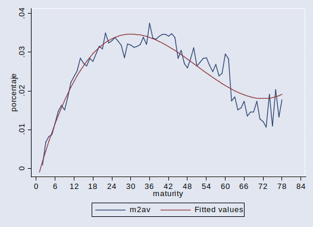

A la vista del gráfico sabemos que la mayor parte de los créditos impagados se producen entre 24 y 36 meses tras la concesión del préstamo. Por lo tanto el periodo de estudio que emplearía sería aquel que contuviera mayor cantidad de información de préstamos en este periodo de vigencia. De esta forma aumento mis probabilidades de conseguir información sobre las características de un impago. Una forma aún más precisa de hacerlo sería asignar a cada periodo un peso proporcional a la curva observada y así asignar una puntuación a cada préstamo en función del periodo en que se encuentre, y luego hacer una ventana temporal que sume la mayor puntuación posible, que contenga la mayor cantidad de observaciones de préstamos entre 20 y 40 meses después de su concesión.

## Ejercicio 13

##### *Una de las fases más importantes en el proceso de la creación de la tarjeta de puntuación es el de la primera selección de las potenciales variables explicativas que podrían incluirse en el modelo de regresión. Por favor explique al menos dos estadísticos que podrían utilizarse para esta tarea de selección inicial, que significan y cómo deben usarse*

Para seleccionar variables podemos emplear diferentes estadísticos, que determinan la capacidad de predicción de la variable sobre una variable objetivo:

- **Valor de Información $(IV)$**: Se emplea con variables cualitativas (o cuantitativas discretizadas) y nos permite ver la información aportada por cada una de las categorías para la discriminación de la variable objetivo, podemos además categorizar las variables según si IV:
  - IV $\lt$ 0.02 –> Variables no predictivas
  - 0.02 $\leq$ IV $\lt$ 0.1 –> Variables de influencia débil
  - 0.1 $\leq$ IV $\lt$ 0.3 –> Variables de influencia media
  - 0.3 $\leq$ IV –> Variables de influencia fuerte

  Matemáticamente se define según:

$$IV = \sum_{i=1}^{nº\ valores}WE_i \cdot \left( \frac{G_i \cdot B - B_i \cdot G}{B \cdot G} \right)\\
\text{siendo: }\ WE_i = \ln \left( \frac{G_i \cdot B}{B_i \cdot G} \right)\ \text{, } G = goods \text{ y }B = bads$$

- **Coeficiente de Gini $(Gini)$**: Se desarrollo como un índice para determinar la desigualdad económica, sin embargo, a día de hoy su uso también se ha ampliado. Igual que el estadístico anterior se emplea únicamente con variables cualitativas (o cuantitativas discretizadas) y también nos permite categorizar las variables según:
  - G $\lt$ 5%: No se recomienda el uso de la variable
  - 5% $\leq$ G $\lt$ 15%: Se puede emplear la variable
  - 15% $\leq$ G: Se recomienda el uso de la variable

  Matemáticamente se define según:

$$Gini = 1 - \frac{2 \cdot \sum_{i=2}^m \left( G_i \cdot \sum_{j=1}^{i-1} B_j \right) + \sum_{k=1}^{m} \left(G_k B_k\right)}{G \cdot B}\\
\text{siendo: } G = goods \text{ y }B = bads$$

- **V de Cramer $(\Phi_C)$**: Al igual que los anteriores se emplea con variables cualitativas (o cuantitativas discretizadas) y también nos permite categorizar las variables según:
  - $\Phi_C$ $\lt$ 0.2: No hay relación entre las variables
  - 0.2 $\leq$ $\Phi_C$ $\lt$ 0.6: Existe una relación moderada entre las variables
  - 0.6 $\leq$ $\Phi_C$: Existe una relación fuerte entre las variables

  Matemáticamente se define, si llamamos $k$ al número de categorías de la variable objetivo, y $l$ al de la variable estudiada, como:

$$\Phi_C = \sqrt{\frac{\chi^2}{N \cdot (\min(k, l) -1)}}\\
\text{siendo: } \chi^2 = \sum_{i=1}^k \sum_{j=1}^l \frac{\left( n_{ij} - \tfrac{n_i n_j}{n} \right)^2}{\frac{n_i n_j}{n}}$$

## Ejercicio 14

##### *Una vez depurada la base de datos, analizados atípicos e imputados, en su caso, los valores perdidos, una vez definida la variable objetivo, dividida la base de datos en muestra de entrenamiento y de validación, y una vez elegidas las variables explicativas que se incluirán en el modelo, procede la estimación de un modelo de probabilidad. Defina y explique las características de un modelo de probabilidad o de variable dependiente binaria, y las limitaciones de este tipo de modelos para realizar la diagnosis de sus residuos y la interpretación de sus coeficientes*

Un **modelo de probabilidad o variable dependiente binaria** es un modelo que diseñado para predecir una variable binaria a partir otras variables. El modelo es por lo tanto una función de enlace (en general una distribución de probabilidad) $G(\overrightarrow{X})$ sobre el espacio de las variables, el valor de esta función puede considerarse una **variable latente**, y la variable objetivo binaria simplemente una función sobre los valores de la función de enlace que toma los valores uno o cero, tenemos varios modelos según su función de enlace: - Modelo Lineal de Probabilidad: Distribución Uniforme - Modelo Probit: Distribución normal - Modelo Logit: Distribución logística - Modelo Gompit: Valor extremo

En un **modelo logit** o de regresión logística, que es el más común, la distribución de probabilidad es:
$$P(y=1 | \vec{X}) = \frac{\exp \left(\beta_0 + \vec{\beta}\cdot \vec{X} \right)}{1 + \exp \left(\beta_0 + \vec{\beta}\cdot \vec{X} \right)}\\
P(y=0 | \vec{X}) = 1 - P(y=1 | \vec{X}) = \frac{1}{1 + \exp \left(\beta_0 + \vec{\beta}\cdot \vec{X} \right)}\\
odds = \frac{P(y=1 | \vec{X})}{P(y=0 | \vec{X})} = \exp \left(\beta_0 + \vec{\beta}\cdot \vec{X} \right)\\
Logit(P) = \ln(odds) = \beta_0 + \vec{\beta}\cdot \vec{X} \longrightarrow Lineal$$
En este caso los coeficientes admiten una interpretación directa (de ahí que se haya extendido su uso), ya que su exponencial representa el *odds ratio* asociado al aumento de la variable una unidad. En modelos con distribuciones diferentes la interpretación de los parámetros implica mayor complejidad. A la hora de estimar los parámetros no podemos emplear mínimos cuadrados, o alguna técnica analítica similar, sino que tenemos que recurrir al **argumento de máxima verosimilitud** que implica asumir que los datos que hemos tomado son los que son porque este evento era el más probable. De esta forma los parámetros se aproximan mediante modelos iterativos y esto implica que solo conozcamos el residuo de los modelos de forma aproximada.

## Ejercicio 15

##### *Relacionado con el punto anterior, comente qué es el porcentaje de pronósticos correctos, y cómo puede utilizarse el umbral para pronosticar si un préstamo será impagado o no.*

Una vez construido el modelo hay varios valores que nos serán de interés:

- Tasa de aciertos: $\frac{VP + VN}{TODOS}$
- Tasa de fallos: $\frac{FP + FN}{TODOS}$
- Sensibilidad (positivos acertados entre totales): $\frac{VP}{VP + FN}$
- Especificidad (negativos acertados entre totales): $\frac{VN}{VN + FP}$
- Valor predictivo positivo (positivos acertados entre pronosticados): $\frac{VP}{VP + FP}$
- Valor predictivo negativo (negativos acertados entre pronosticados): $\frac{VN}{VN + FN}$

Dado que lo que tenemos es esa variable latente que asigna a cada observación, en función de los valores de algunas variables, un valor entre 0 y 1, podemos elegir cualquier punto de corte a partir del cual valores mayores sean uno y menores cero. A esto lo llamamos **umbral**, los prétamos que lo superen se calificarán como impagados. No obstante este umbral lo definimos nosotros, con lo que dependiendo el valor que elijamos tendremos mayor o menor número de préstamos pronosticados como impagados. Para elegir el punto de corte podemos también emplear varios criterios diferentes, en función de qué prioricemos:

- El punto que maximiza la tasa de aciertos
- El punto que maximiza el índice de Youden: $Youden = sensibilidad + especificidad -1$
- El punto que, fijada una especifidad mínima, maximiza la sensibilidad
- El punto que, fijada una sensibilidad mínima, maximiza la especificidad

##### *Explique brevemente qué es la curva ROC y cómo debe interpretarse, ¿sobre que muestra cree que es mejor realizar la diagnosis utilizando esta curva, con la muestra de entrenamiento o con la de validación?. Justifique su respuesta.*

Para conocer la bondad de nuestro modelo se emplea la curva ROC (acónimo de Receiver Operating Characteristic) que es una representación de la sensibilidad del modelo frente a uno menos la especificidad. Esto implica que cuanto más próxima esté a la esquina superior izquierda del gráfico (sensibilidad = 1, especificidad = 1) mejor será el modelo. Normalmente se emplea el área bajo la curva como un estimador de la bondad del modelo, también podríamos elegir como punto de corte el punto de la curva que se encontrase a menor distancia del vértice antes señalado.

## Ejercicio 16

##### *Explique brevemente qué es “la inferencia de denegados”, cuándo conviene realizarla y por qué*

La inferencia de denegados es una técnica que se solventar el hecho de que la muestra empleada recoge únicamente los prétamos otorgados, y no aquellos que se rechazaron, es decir, de los préstamos que no otorgamos no sabemos si serían impagados o no, se produce así un sesgo derivado de la selección de la muestra que puede conducir al modelo a infravalorar la probabilidad de impago. Para salvar este sesgo se emplea la **inferencia de denegados** que se aplica fundamentalmente mediante cuatro técnicas, asignar todos los préstamos no otorgados a la categoría de impagados, asignar a los denegados la categoría que defina el modelo creado, estableciendo un ‘’cut-off’’, añadir una variable con la probabilidad asignada con el modelo generado con los préstamos aceptados multiplicada por un ratio definido por nosotros y desdoblar cada denegado en 2, uno con la probabilidad de impago y como si hubiera impagado, otro con la probabilidad de pago y como si hubiera pagado, por último esta la opción de asignarles un valor aleatorio pocedente de la distribución que presentan los prestamos aceptados que obtienen la misma probabilidad con el modelo de aceptados.

## Ejercicio 17

##### *Construya una tarjeta de puntuación de riesgos de impago con el conjunto de datos del fichero “datriesgos.RData” siguiendo la metodología propuesta en clase. El fichero contiene:*

- **Variable objetivo:**
  - Impago (1 SI impago, 0 NO impago)
- **Variables explicativas:**
  - loan_amnt (Importe del pretamo)
  - int_rate (Interes aplicado)
  - calidad_crediticia (A - G siendo A menor riesgo)
  - emp_length (antiguedad del empleo)
  - home_ownership (1 propietario, 0 NO propietario)
  - annual_inc (ingresos anuales del cliente)
  - age (edad)

En este ejercicio he puesto bastante esfuerzo así que voy a ir comentando el código poco a poco. En primer lugar, como siempre, he cargado las librerías y los datos, le he echado un ojo, y he definido algunas funciones que usaré de forma recurrente. Conviene señalar que es más que recomendable leerse el código ya que está llenos de apuntes sobre los resultados.

```r
# Descripción: Cálculo de una scorecard usando el paquete de R "scorecard"
setwd("~/Desktop/Santi/master_BD/temporal_analisis/entrega/")
# 0. Cargo librerias ----
# Traditional Credit Scoring Using Logistic Regression
library(stargazer)
library(mfx) # para efectos marginales
library(scorecard)
library(outliers)
library(gmodels) #CrossTable()
library(car)
library(ggplot2)
library(gridExtra)
library(onewaytests) #para el test welch
library(caret)
library(questionr)

## 0.1 Funciones útiles ----
Vcramer<-function(v,target){
  if (is.numeric(v)){
    v<-cut(v,5)
  }
  if (is.numeric(target)){
    target<-cut(target,5)
  }
  cramer.v(table(v,target))
}

graficoVcramer<-function(matriz, target, title){
  salidaVcramer<-sapply(matriz,function(x) Vcramer(x,target))
  barplot(sort(salidaVcramer,decreasing =T),las=2,main=title, horiz=TRUE,
          cex.axis=0.65, xlim=c(0,1))
}

myDistPlot<- function(datos, var1, var2, title){
  ggplot(datos, aes_string(x=var1, fill=var2)) +
    geom_density(alpha=.3, show.legend = FALSE) + ggtitle(title)
}

myBoxPlot<- function(datos, var1, var2, varbin, title, leg){
  ggplot(datos, aes_string(x=var1, y=var2, fill=varbin)) + geom_boxplot(alpha=.3, show.legend = leg) +
    stat_summary(fun.y=mean, colour="darkolivegreen", geom="point", shape=18, size=3,
                 position=position_dodge(width=0.75), show_guide = FALSE) +
    ggtitle(title)
}

# Rellena los missings en var1 con valores de var1 parecidos a entradas con valores similares de var2
rellenaMissings<- function(dat, var1, var2, no.lower){
  dat$var2.fac<- cut(dat[[var2]], 5)
  missings<- dat[is.na(dat[[var1]]),c(var1, var2, "var2.fac")]
  not.missings<- dat[!is.na(dat[[var1]]), c(var1, var2, "var2.fac")]
  inputator<- as.data.frame(aggregate(not.missings[,1], list(not.missings$var2.fac), mean))
  inputator$sd<- aggregate(not.missings[,1], list(not.missings$var2.fac), sd)$x
  set.seed(12345)
  if(no.lower){
    aleat<- runif(nrow(missings), 0, 1)
  }else{
    aleat<- runif(nrow(missings), -1, 1)
  }
  for(i in seq(1,nrow(missings))){
    miss.group<- missings$var2.fac[i]
    al<- aleat[i]
    val<- inputator[inputator$Group.1 == miss.group, 2] + al * inputator[inputator$Group.1 == miss.group, 3]
    dat[rownames(missings)[i],var1]<- val
  }
  return(dat[, -ncol(dat)])
}

# 1.Cargo los datos ----
load("datriesgos.RData")
datos<- datriesgos
#Visualización
datos
```

|  | impago | loan_amnt | int_rate | Calidad_Crediticia | emp_length | home_ownership | annual_inc | age |
| --- | --- | --- | --- | --- | --- | --- | --- | --- |
| 1 | 0 | 5000 | 10.65 | B | 10 | RENT | 24000.00 | 33 |
| 2 | 0 | 2400 | NA | C | 25 | RENT | 12252.00 | 31 |
| 3 | 0 | 10000 | 13.49 | C | 13 | RENT | 49200.00 | 24 |
| 4 | 0 | 5000 | NA | A | 3 | RENT | 36000.00 | 39 |
| 5 | 0 | 3000 | NA | E | 9 | RENT | 48000.00 | 24 |
| 6 | 0 | 12000 | 12.69 | B | 11 | OWN | 75000.00 | 28 |
| 7 | 1 | 9000 | 13.49 | C | 0 | RENT | 30000.00 | 22 |
| 8 | 0 | 3000 | 9.91 | B | 3 | RENT | 15000.00 | 22 |
| 9 | 1 | 10000 | 10.65 | B | 3 | RENT | 100000.00 | 28 |
| 10 | 0 | 1000 | 16.29 | D | 0 | RENT | 28000.00 | 22 |

[output cut: 9990 more lines]

```r
str(datos)
## 'data.frame':    29092 obs. of  8 variables:
##  $ impago            : int  0 0 0 0 0 0 1 0 1 0 ...
##  $ loan_amnt         : int  5000 2400 10000 5000 3000 12000 9000 3000 10000 1000 ...
##  $ int_rate          : num  10.7 NA 13.5 NA NA ...
##  $ Calidad_Crediticia: Factor w/ 7 levels "A","B","C","D",..: 2 3 3 1 5 2 3 2 2 4 ...
##  $ emp_length        : int  10 25 13 3 9 11 0 3 3 0 ...
##  $ home_ownership    : Factor w/ 4 levels "MORTGAGE","OTHER",..: 4 4 4 4 4 3 4 4 4 4 ...
##  $ annual_inc        : num  24000 12252 49200 36000 48000 ...
##  $ age               : int  33 31 24 39 24 28 22 22 28 22 ...
```

Como se puede observar se trata de un set con 8 variables y 29092 observaciones, luego la proporción nos va a permitir tener un modelo con un número de parámetros razonable (por el número de variables) y bien ajustado (por el número de observaciones).